# Adding time to the daughter equations

The equations from the first couple of exploratory notebooks were stationary i.e. assume the mortality and fertility rates don’t change over time. It would be nice to be able to make these a bit more realistic and add a time varying component to this.

For the daughter and grand-daughter equations, We know how old the mother is (age $A$ at time $t$) so everything can be indexed based on that. Time-indexing the fertility rates should be straight forward. For example, fertility rates at age $x$ would be $_nF_x (t - (A-x))$.

For the $L_x$’s we can recalculate ‘cohort’ measures based on the information we have: use the 5-year $_np_x$’s from the appropriate cohorts to reconstruct $L_x$’s that would be closer to cohort measures.

The problem with both of these approaches is that we quickly run out of data: for the WPP that we have, which spans 1950-2010, we could only get cohort-based measures of number of daughters surviving in 2010 for the 1935-1955 cohorts, for example.

An alternative potential fix using period data is to index the fertility / (mortality?) data based on mean age at child bearing: for example, for the 1950 cohort, consider data from 1980.

This notebook shows how to calculate cohort-based measures, and shows how they vary quite a bit from the stationary measures calculated earlier. Calculations are then done based on using period data corresponding to mean age at childbearing years.

Read in the data:

```r
library(tidyverse)
library(here)
source(here("code", "kin_functions.R"))
lt <- read_csv(here("data", "wpp_lt.csv"))
fx <- read_csv(here("data", "wpp_fx.csv"))
```

Tidy up the data:

```r
df_mort <- lt %>%
  # tidy up names
  rename(year = Period,
         region = `Region, subregion, country or area *`,
         age = `Age (x)`,
         Lx = `Number of person-years lived L(x,n)`) %>%
  # just keep the columns we need
  select(year, region, age, Lx)
# fertility df
df_fert <- fx %>%
  # tidy up names
  rename(year = Period,
         region = `Region, subregion, country or area *`) %>%
  # only keep years/ages/countries we want
  select(year, region, `15-19`:`45-49`) %>%
  # change to long format
  gather(age_group, Fx, -year, -region) %>%
  # make an age column
  mutate(age = as.numeric(substring(age_group, 1, 2)))
# join the two bits, and fill in the missing info (fertility only goes to age 49)
df <- df_mort %>%
  left_join(df_fert) %>%
  mutate(age_group = paste(age, age+4, sep = "-"),
         Fx = ifelse(is.na(Fx), 0, Fx)) %>%
  rename(period = year) %>%
  mutate(year = as.numeric(substring(period, 1,4)))
## make the first two age groups into one
df <- df %>% group_by(year, region) %>%
  mutate(Lx = ifelse(age==0, Lx[age==0]+Lx[age==1], Lx)) %>%
  filter(age!=1) %>%
  ungroup()
```

Make a cohort version of the mortality data:

```r
df_cohort <- lt %>%
  # tidy up names
  rename(period = Period,
         region = `Region, subregion, country or area *`,
         age = `Age (x)`,
         Lx = `Number of person-years lived L(x,n)`,
         px = `Probability of surviving p(x,n)`,
         dx = `Number of deaths d(x,n)`,
         ax = `Average number of years lived a(x,n)`) %>%
  mutate(px = as.numeric(px)) %>%
  # just keep the columns we need
  select(period, region, age, Lx, px, dx, ax) %>%
  mutate(year = as.numeric(substring(period, 1,4))) %>%
  mutate(cohort = year - age) %>%
  group_by(year, region) %>%
  mutate(Lx = ifelse(age==0, Lx[age==0]+Lx[age==1], Lx),
         px = ifelse(age==0, px[age==0]*px[age==1], px),
         dx = ifelse(age==0, dx[age==0]+dx[age==1], dx),
         ax = ifelse(age==0, ax[age==0]+ax[age==1], ax)) %>%
  filter(age!=1) %>%
  ungroup()
```

```
NAs introduced by coercion
```

```r
cohorts <- seq(1935, 2010, by = 5)
regions <- unique(df$region)
d_all <-c()
for(k in 1:length(regions)){
  dc <- c()
  for(i in 1:length(cohorts)){
    d_cohort <- df_cohort %>% filter(region == regions[k], cohort == cohorts[i])
    d_cohort$lx <- 1
    d_cohort$dx_cohort <- NA
    d_cohort$Lx_cohort <- NA
    ages_in_cohort <- d_cohort$age
    if(length(ages_in_cohort)>2){
      for(j in 2:length(ages_in_cohort)){
        d_cohort$lx[j] <- d_cohort$lx[j-1]*d_cohort$px[j]
      }
      for(j in 1:(length(ages_in_cohort)-1)){
        d_cohort$dx_cohort[j] <- d_cohort$lx[j] - d_cohort$lx[j+1]
        d_cohort$Lx_cohort[j] <- (5*d_cohort$lx[j+1] + d_cohort$ax[j]* d_cohort$dx_cohort[j])*100000
      }
      d_cohort$dx_cohort[length(ages_in_cohort)] <- 2*d_cohort$dx_cohort[(length(ages_in_cohort)-1)] - d_cohort$dx_cohort[(length(ages_in_cohort)-2)]
      d_cohort$Lx_cohort[length(ages_in_cohort)] <- (5*(d_cohort$lx[length(ages_in_cohort)] - d_cohort$dx_cohort[length(ages_in_cohort)]) + d_cohort$ax[length(ages_in_cohort)]* d_cohort$dx_cohort[length(ages_in_cohort)])*100000
      dc <- rbind(dc, d_cohort)
    }

  }
  d_all <- rbind(d_all, dc)
}
```

Join on the fertility data:

```r
d_all <- d_all %>%
  left_join(df_fert %>% rename(period = year) %>%  mutate(year = as.numeric(substring(period, 1,4)))) %>%
  mutate(Fx = ifelse(is.na(Fx), 0, Fx))
```

Now compare this cohort-based measure to the stationary measure used before. Try 75 year olds in Kenya in 2010, there’s a difference on 1 person.

```r
age_a <- 75
year <- 2010
mother_cohort <- year - age_a
d <- d_all %>% filter(region == "Kenya")
ffab <- 0.4886
x_vec <- seq(15,age_a, by = 5)
daughter_cohorts <- year - (age_a - x_vec)
# calculate based on cohorts
LF_prod <- c()
for(i in 1:length(x_vec)){
  this_L <- d %>% filter(age == age_a - x_vec[i], cohort == daughter_cohorts[i]) %>% select(Lx_cohort) %>% pull()
  this_F <- d %>% filter(age == x_vec[i], cohort == mother_cohort) %>% select(Fx) %>% pull()
  LF_prod <- c(LF_prod, this_L/10^5*this_F/10^3*ffab)
}
sum(LF_prod)
```

```
[1] 2.632597
```

```r
# original stationary measure
surviving_daughters(df %>% filter(year==2010, region == "Kenya"), age_a)
```

```
[1] 1.623907
```

For low mortality/ fertlity country like Australia, there’s still a difference, but it’s much smaller:

```r
age_a <- 75
year <- 2010
mother_cohort <- year - age_a
d <- d_all %>% filter(region == "Australia")
ffab <- 0.4886
x_vec <- seq(15,age_a, by = 5)
daughter_cohorts <- year - (age_a - x_vec)
# calculate based on cohorts
LF_prod <- c()
for(i in 1:length(x_vec)){
  this_L <- d %>% filter(age == age_a - x_vec[i], cohort == daughter_cohorts[i]) %>% select(Lx_cohort) %>% pull()
  this_F <- d %>% filter(age == x_vec[i], cohort == mother_cohort) %>% select(Fx) %>% pull()
  LF_prod <- c(LF_prod, this_L/10^5*this_F/10^3*ffab)
}
sum(LF_prod)
```

```
[1] 1.402847
```

```r
# original stationary measure
surviving_daughters(df %>% filter(year==2010, region == "Australia"), age_a)
```

```
[1] 0.8964131
```

```r
#Kenya:
age_a <- 75
year <- 2010
mother_cohort <- year - age_a
d <- df %>% filter(region == "Kenya")
ffab <- 0.4886
x_vec <- seq(15,age_a, by = 5)
# calculate based on period of mean childbearing age = 30
LF_prod <- c()
for(i in 1:length(x_vec)){
  this_L <- d %>% filter(age == age_a - x_vec[i], year == mother_cohort+30) %>% select(Lx) %>% pull()
  this_F <- d %>% filter(age == x_vec[i], year == mother_cohort+30) %>% select(Fx) %>% pull()
  LF_prod <- c(LF_prod, this_L/10^5*this_F/10^3*ffab)
}
sum(LF_prod)
```

```
[1] 2.46891
```

```r
# Australia:
age_a <- 75
year <- 2010
mother_cohort <- year - age_a
d <- df %>% filter(region == "Australia")
ffab <- 0.4886
x_vec <- seq(15,age_a, by = 5)
# calculate based on period of mean childbearing age = 30
LF_prod <- c()
for(i in 1:length(x_vec)){
  this_L <- d %>% filter(age == age_a - x_vec[i], year == mother_cohort+30) %>% select(Lx) %>% pull()
  this_F <- d %>% filter(age == x_vec[i], year == mother_cohort+30) %>% select(Fx) %>% pull()
  LF_prod <- c(LF_prod, this_L/10^5*this_F/10^3*ffab)
}
sum(LF_prod)
```

```
[1] 1.273651
```

Try and make this a bit more automated. Load in functions

```r
source(here("code", "alternative_daughters.R"))
ages <- seq(55, 75, by = 5)
year_test <- 2010
countries <- c("United States of America",
               "Japan",
               "Australia",
               "Kenya",
               "Nigeria",
               "Ireland",
               "Yemen",
               "Bangladesh",
               "Venezuela (Bolivarian Republic of)",
               "Mexico",
               "Canada",
               "China")
res <- tibble(country = NA, age = NA, cohort = NA, meanage = NA, meanage_adjust = NA, stat = NA)
for(i in 1:length(countries)){
  d_cohort <- d_all %>% filter(region == countries[i])
  d_period <- df %>% filter(region == countries[i])
  d_stat <- df %>% filter(region==countries[i], year==2010)
  for(j in 1:length(ages)){
    res <- rbind(res, tibble(country = countries[i],
                              age = ages[j],
                             cohort = surviving_daughters_cohort(df = d_cohort, year = year_test, age_a = ages[j]),
                             meanage = surviving_daughters_mean_age(df = d_period,
                                                                    year = year_test, age_a = ages[j], mean_age = 25),
                             meanage_adjust = surviving_daughters_mean_age_adjustment(df = d_period,
                                                                    year = year_test, age_a = ages[j], mean_age = 25),
                             stat = surviving_daughters(df = d_stat, age_a = ages[j])))
  }
}
res <- res[-1,]
res
```

| country | age | cohort | meanage | meanage_adjust | stat |
| --- | --- | --- | --- | --- | --- |
| United States of America | 55 | 0.9535288 | 0.8663587 | 0.9535288 | 0.9027297 |
| United States of America | 60 | 0.9702367 | 0.8458609 | 0.9702367 | 0.8985725 |
| United States of America | 65 | 1.0714710 | 0.9607411 | 1.0714710 | 0.8925232 |
| United States of America | 70 | 1.2599937 | 1.1900737 | 1.2599937 | 0.8834969 |
| United States of America | 75 | 1.4178605 | 1.4868208 | 1.4178605 | 0.8701684 |
| Japan | 55 | 0.9508927 | 0.8538348 | 0.9508927 | 0.6833003 |
| Japan | 60 | 0.9726686 | 0.8849636 | 0.9726686 | 0.6818940 |
| Japan | 65 | 0.9630822 | 1.0277070 | 0.9630822 | 0.6799188 |
| Japan | 70 | 0.9769716 | 0.9772573 | 0.9769716 | 0.6770111 |
| Japan | 75 | 0.9776548 | 0.9646340 | 0.9776548 | 0.6726872 |

[output cut: 50 more lines]

Plot

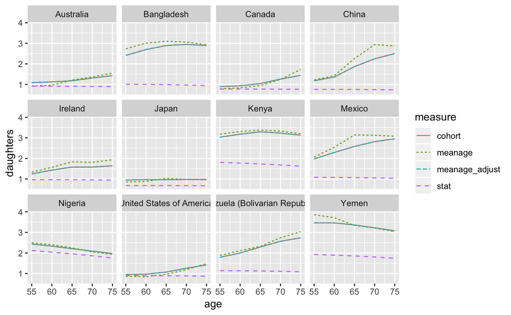

Ignoring mortality changes (which we don’t want to do, but I’m doing for now), the mean age measure is much closer to the cohort measure, and the adjusted mean age measure is exactly the same. Oh because it’s just getting the cohort fertility rates. Silly me. this doesn’t help.

Look at percent differences between cohort and mean age

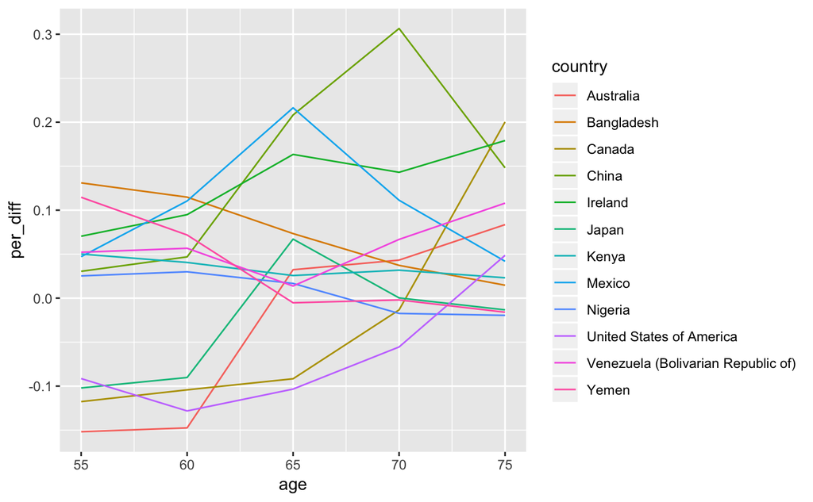

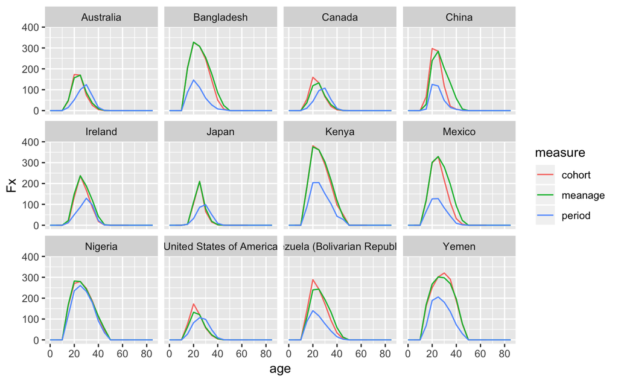

```r
f_cohort <- d_all %>%  filter(cohort == 1945, region %in% countries) %>% select(region, age, Fx) %>% mutate(measure = "cohort")
f_period <- df %>% filter(year==2010, region %in% countries) %>% select(region, age, Fx) %>% mutate(measure = "period")
f_meanage <- df %>% filter(year==1970, region %in% countries) %>% select(region, age, Fx) %>% mutate(measure = "meanage")
f_all <- bind_rows(f_cohort, f_period, f_meanage)
ggplot(f_all, aes(age, Fx, color = measure)) + geom_line() + facet_wrap(~region)
```

Need a way of essentially adjusting the period mean age schedules to look more like cohort schedules.

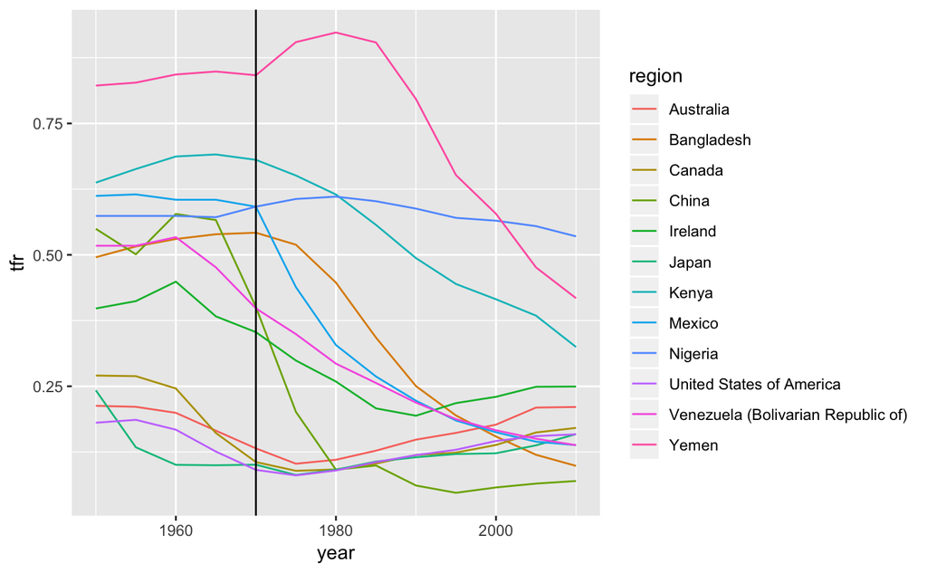

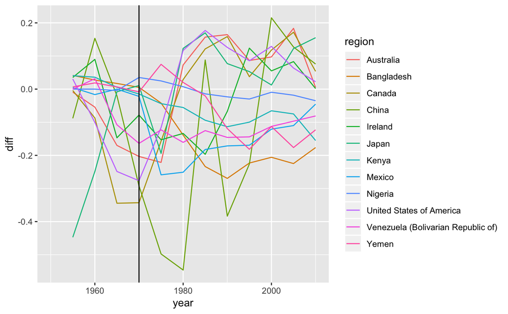

```r
adjs <- df %>%
  filter(region %in% countries, age >25, year >1965, year < 1995) %>%
  group_by(region, year) %>%
  summarise(tfr = sum(Fx/1000)) %>%
  mutate(diff = (tfr - lag(tfr))/lag(tfr)) %>%
  #filter(year>1965, year< 1995) %>%
  group_by(region) %>%
  summarise(ave = mean(diff, na.rm = T))
```

```r
this_year <- year
country <- "China"
mother_cohort <- year - age_a
x_vec <- seq(15,age_a, by = 5)
mean_age <- 25

  # calculate based on period of mean childbearing age = 30
  LF_prod <- c()
  for(i in 1:length(x_vec)){
    this_L <- df %>% filter(age == age_a - x_vec[i], year==this_year, region == country) %>% select(Lx) %>% pull()
    this_F <- df %>% filter(age == x_vec[i], year == mother_cohort+mean_age, region == country) %>% select(Fx) %>% pull()
    adjustment_F <- ifelse(x_vec[i]>mean_age,adjs$ave[adjs$region==country], 0)
    this_F_adjust <- this_F*(1+adjustment_F)
    LF_prod <- c(LF_prod, this_L/10^5*this_F_adjust/10^3*ffab)
  }

  sum(LF_prod)
```

```
[1] 2.416396
```